# Лабораторная работа №1

Julia: установка, настройка и основные принципы

Ведьмина Александра Сергеевна

1132236003@rudn.ru

Российский университет дружбы народов

2026-09-09

## Содержание

- Цель и задачи
- Подготовка окружения
- Проект `DrWatson`
- Основы Julia
- Ввод-вывод и `parse`
- Векторы и матрицы
- Параметрический расчёт
- Результаты и выводы

# Информация

## Докладчик

- Ведьмина Александра Сергеевна
- студентка
- кафедра теории вероятностей и кибербезопасности
- Российский университет дружбы народов
- 1132236003@rudn.ru

# Вводная часть

## Цель работы

Подготовить рабочее пространство для Julia и познакомиться с основами языка на выполненных примерах.

Задачи:

- установить Julia, Jupyter Lab и IJulia;
- создать воспроизводимый проект `DrWatson`;
- изучить типы, функции, ввод-вывод и массивы;
- провести параметрический расчёт;
- получить Julia-, `ipynb`- и `qmd`-представления;
- проверить проект тестами.

## Использованные инструменты

- Julia `1.12.5`;
- Jupyter Lab и IJulia;
- `DrWatson` для структуры проекта;
- `DataFrames`, `CSV`, `JLD2` для данных;
- `Plots` для визуализации;
- `DifferentialEquations` для решения ОДУ;
- `Literate` и Quarto для производных документов;
- `Test` для автоматической проверки.

# Подготовка окружения

## Julia и Jupyter

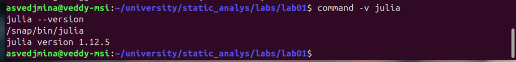

Проверена Julia `1.12.5`.

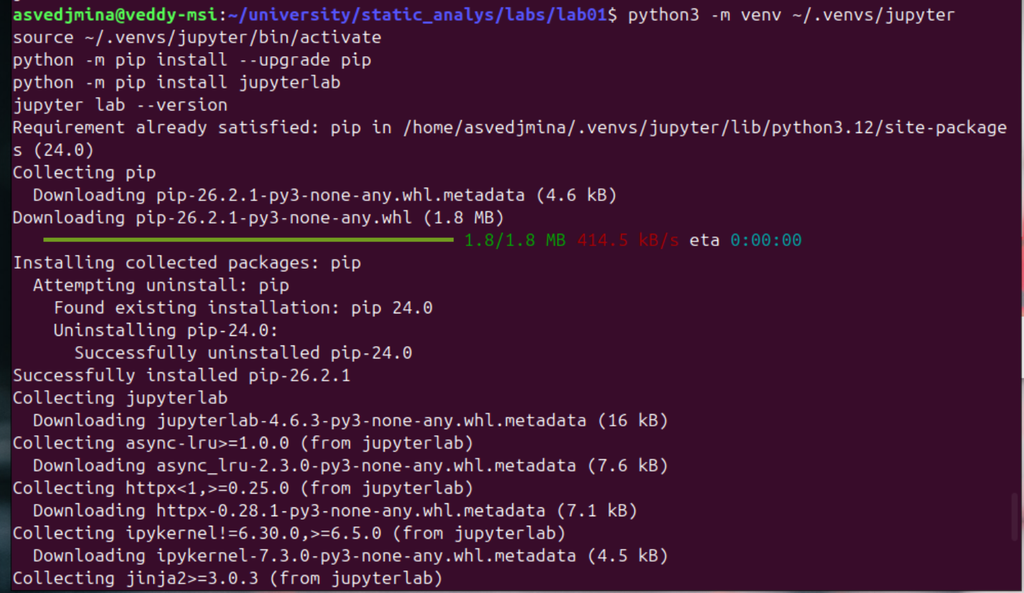

Jupyter установлен в отдельное окружение.

## Ядро IJulia

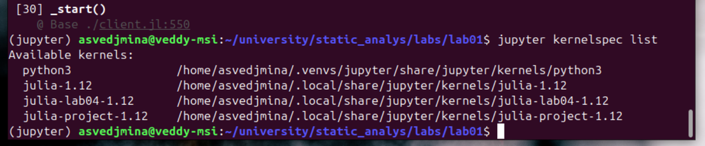

- `IJulia` связана с системным Jupyter;
- зарегистрировано ядро Julia `1.12`;
- notebook можно выполнять непосредственно в Jupyter Lab.

# Проект `DrWatson`

## Создание структуры проекта

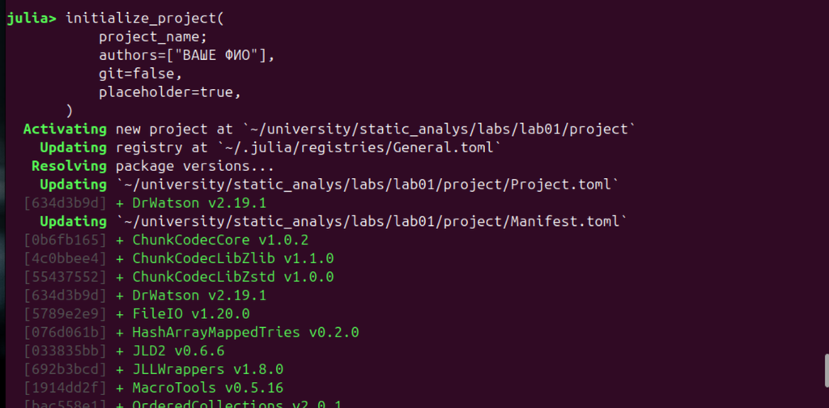

- `Project.toml` и `Manifest.toml`;
- `scripts/` — сценарии;
- `src/` — вычислительные функции;
- `data/` — результаты;
- `plots/` — графики;
- `test/` — автоматические тесты.

## Проверка окружения

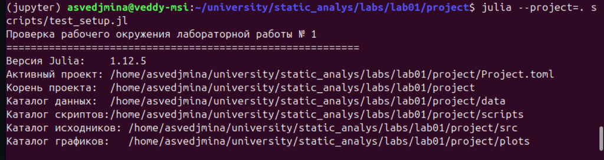

# Основы Julia

## Типы и функции

```julia
values = (3, 3.5, 3 / 3.5, 3 + 4im, pi)
typeof.(values)

Int64(2.0), convert(Char, 65)
promote(Int8(1), Float16(4.5), Float32(4.1))

function square(x)
    return x^2
end
cube(x) = x^3
```

- рассмотрены `Inf`, `-Inf` и `NaN`;
- определены диапазоны знаковых и беззнаковых целых типов;
- показаны два способа определения функций.

## Результаты работы с типами

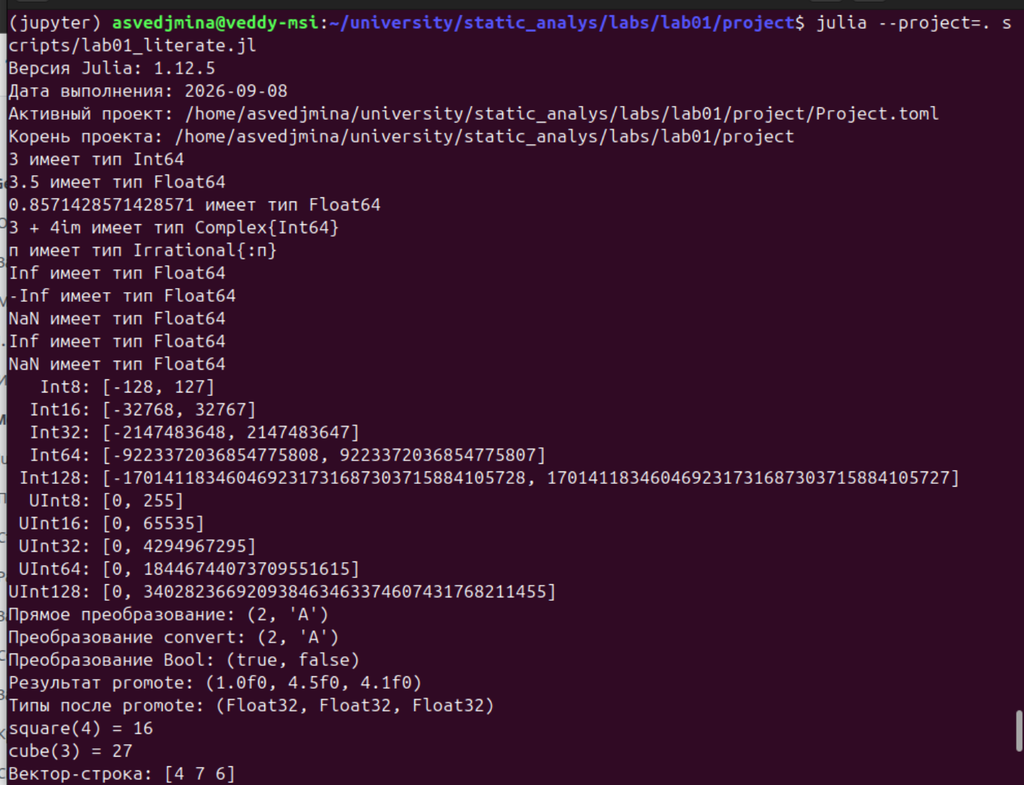

- `promote` привёл значения к `Float32`;
- `square(4) = 16`;
- `cube(3) = 27`.

## Ввод-вывод и `parse`

```julia
read(file, String)
readline(io)
readlines(file)
readdlm(file, ',', Float64)
print(value)
println(value)
show(value)
write(file, bytes)
```

```julia
parse(Int, "42")
parse(Float64, "3.1415")
parse(Bool, "true")
parse(Int, "1010"; base=2)
parse(Int, "ff"; base=16)
tryparse(Int, "abc")
```

`tryparse` возвращает `nothing`, если строку невозможно преобразовать.

## Векторы и матрицы

```julia
v = [1.0, 2.0, 3.0]
w = [4.0, 5.0, 6.0]
A = [1.0 2.0 3.0;
     4.0 5.0 6.0;
     7.0 8.0 10.0]

v + w             # сложение
dot(v, w)         # скалярное произведение
transpose(v)      # транспонирование
A * v             # матрица на вектор
A .* A            # поэлементная операция
```

# Параметрический эксперимент

## Алгоритм расчёта

Для $\alpha \in \{0.5, 1.0, 2.0\}$ вычислялись

$$A_{\alpha}=\alpha A, \qquad
r_{\alpha}=A_{\alpha}v, \qquad
n_{\alpha}=\lVert A_{\alpha}\rVert_F.$$

```julia
function calculate_for_parameter(alpha, matrix, vector)
    scaled_matrix = alpha .* matrix
    result_vector = scaled_matrix * vector
    return (alpha=alpha,
            matrix_norm=norm(scaled_matrix),
            result=result_vector)
end
```

## Численные результаты

| $\alpha$ | Норма | Результирующий вектор |
| --- | --- | --- |
| 0,5 | 8,7178 | `[7.0, 16.0, 26.5]` |
| 1,0 | 17,4356 | `[14.0, 32.0, 53.0]` |
| 2,0 | 34,8712 | `[28.0, 64.0, 106.0]` |

Результаты сохранены в CSV и JLD2. Дополнительно решено уравнение

$$u'=-u, \qquad u(0)=1.$$

## Зависимость нормы от параметра

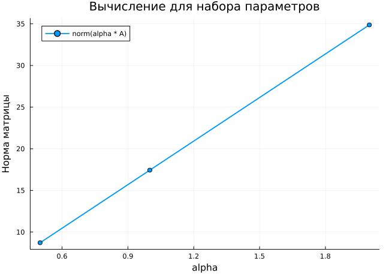

При положительном $\alpha$ норма масштабированной матрицы изменяется линейно.

# Воспроизводимые результаты

## Генерация документов

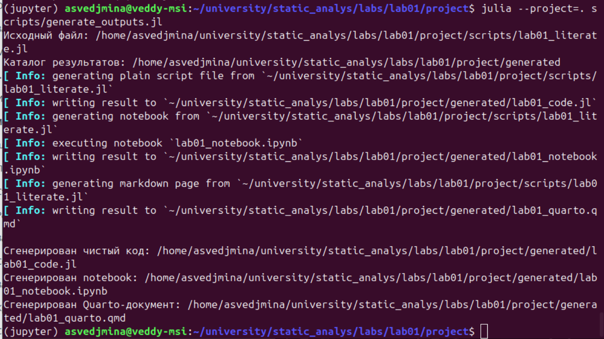

Из одного literate-источника сформированы файлы в `generated/`:

- `lab01_code.jl`;
- `lab01_notebook.ipynb`;
- `lab01_quarto.qmd`.

## Выполненный notebook

[figure not shown]

[figure not shown]

- выполнены все `18` кодовых ячеек;
- ошибочных выводов нет;
- результаты и пояснения находятся в одном документе.

## Quarto и автоматические тесты

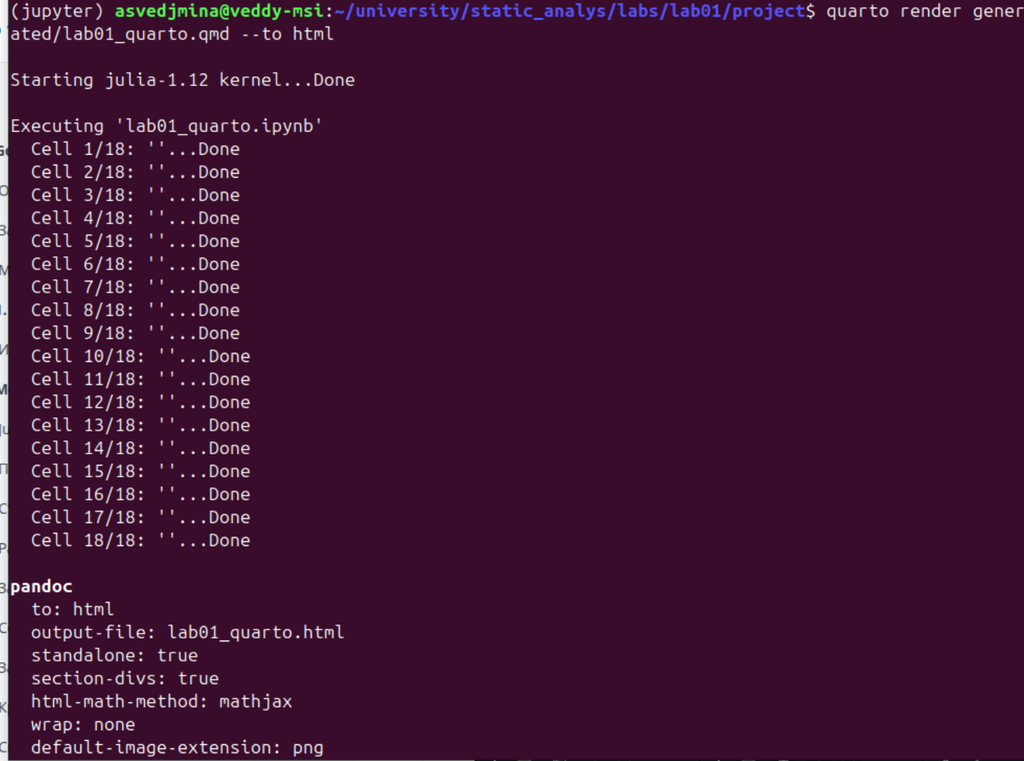

Все ячейки Quarto выполнены.

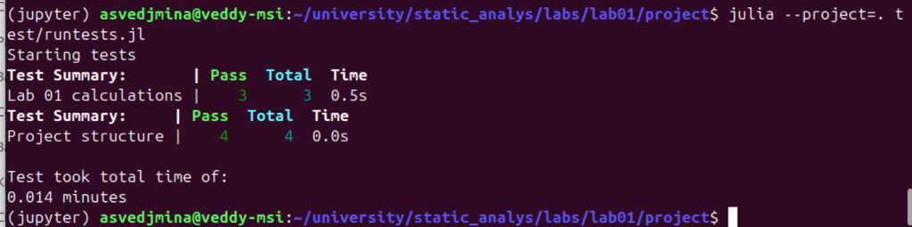

Все `7` тестов пройдены.

# Выводы

## Итоги работы

- настроены Julia, Jupyter Lab и IJulia;
- создан воспроизводимый проект `DrWatson`;
- изучены типы, преобразования, функции и ввод-вывод;
- выполнены операции с векторами и матрицами;
- проведён параметрический расчёт и построен график;
- решён пример ОДУ;
- из одного источника получены код, notebook и Quarto-документ;
- все ячейки и автоматические тесты выполнены без ошибок.

Цель лабораторной работы достигнута.